# MAE augmentation - Additionnal descriptive analyses

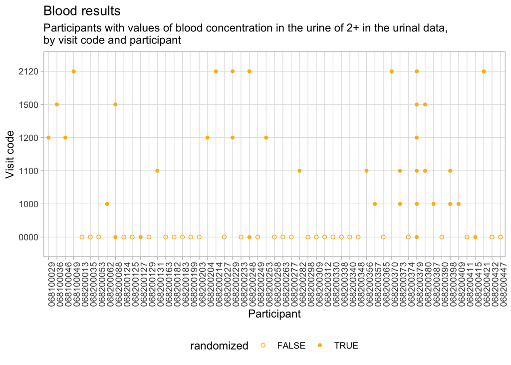

```r
urinalysis |>
  filter(!is.na(blood)) |>
  filter(blood == "2+") |>
  select(pid, study_day, visit_code, randomized, visit_type, site, blood) |>
  ggplot() +
  aes(y = visit_code, x = pid, shape = randomized) +
  geom_point(color = "darkgoldenrod1") +
  scale_shape_manual(values = c(1, 16)) +
  theme(legend.position = "bottom", axis.text.x = element_text(angle = 90)) +
  labs(
    title = "Blood results",
    subtitle = "Participants with values of blood concentration in the urine of 2+ in the urinal data, \nby visit code and participant",
    y = "Visit code",
    x = "Participant"
  )
```

At each clinical visit, participant `068200379` has systematically a value of +2 for blood concentration in the urine.

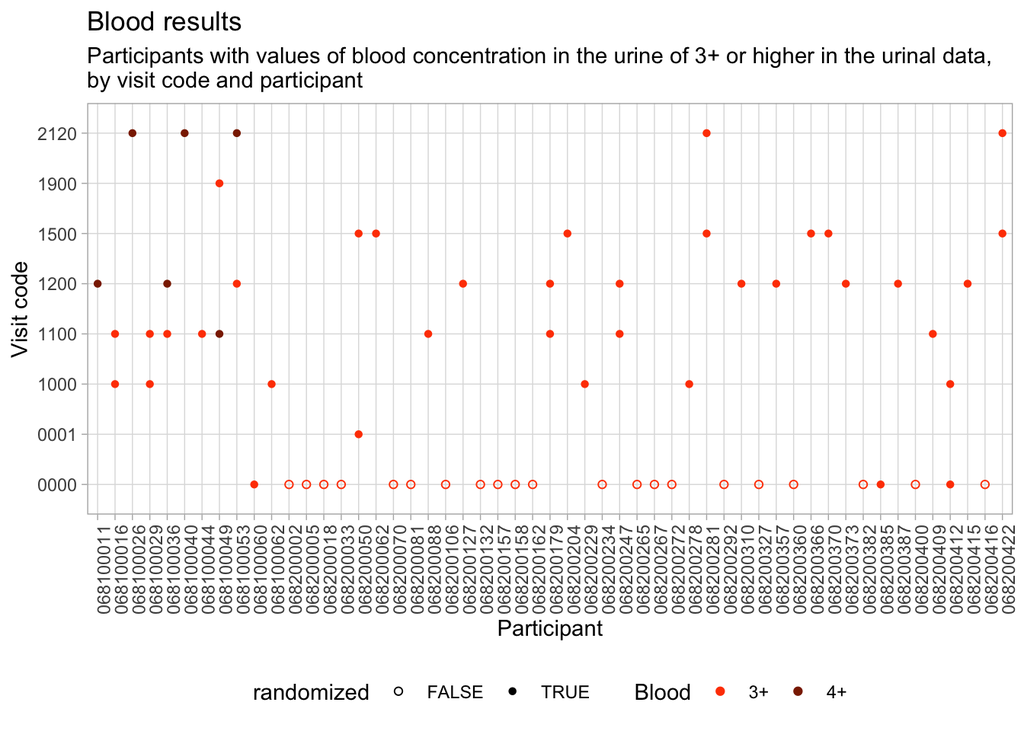

```r
urinalysis |>
  filter(!is.na(blood)) |>
  filter(blood == "3+" | blood == "4+") |>
  select(pid, study_day, visit_code, randomized, visit_type, site, blood) |>
  ggplot() +
  aes(y = visit_code, x = pid, color = blood, shape = randomized) +
  geom_point() +
  scale_color_manual(values = c("3+" = "orangered", "4+" = "orangered4")) +
  scale_shape_manual(values = c(1, 16)) +
  theme(legend.position = "bottom", axis.text.x = element_text(angle = 90)) +
  labs(
    title = "Blood results",
    subtitle = "Participants with values of blood concentration in the urine of 3+ or higher in the urinal data, \nby visit code and participant",
    y = "Visit code",
    x = "Participant"
  )
```

Several participants, such as `068100029`, `068100036` and `068100049` have overall high values of blood concentration, overlapping with the menstruation status of the participants at the corresponding visit codes (at least for samples comprised between visit code 0000 and visit code 1500).

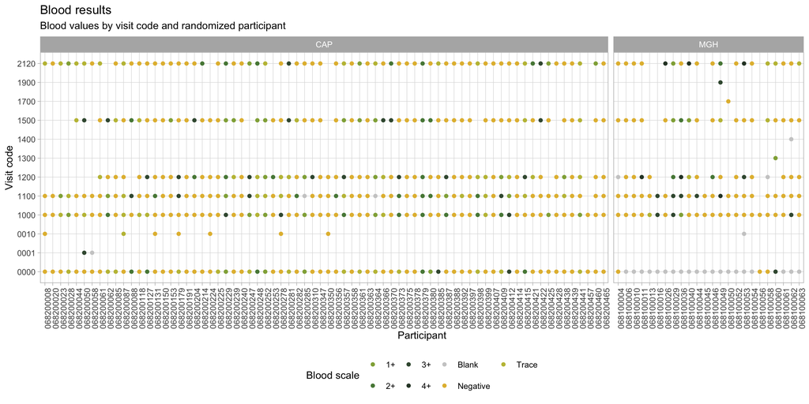

```r
# blood

blood_colors <- c(
  "Negative" = "#e3ba3c",
  "Trace" = "#c0be43",
  "1+" = "#91ac45",
  "2+" = "#568745",
  "3+" = "#3d573e",
  "4+" = "#2e4230",
  "Blank" = "grey80"
)

urinalysis |>
  filter(!is.na(blood)) |>
  filter(randomized) |>
  ggplot() +
  aes(y = visit_code, x = pid, color = blood) +
  geom_point() +
  scale_color_manual(values = blood_colors) +
  facet_wrap(~site, scales = "free_x", space = "free_x") +
  theme(
    legend.position = "bottom",
    axis.text.x = element_text(angle = 90, hjust = 1)
  ) +
  labs(
    title = "Blood results",
    subtitle = "Blood values by visit code and randomized participant",
    y = "Visit code",
    x = "Participant",
    color = "Blood scale"
  )
```

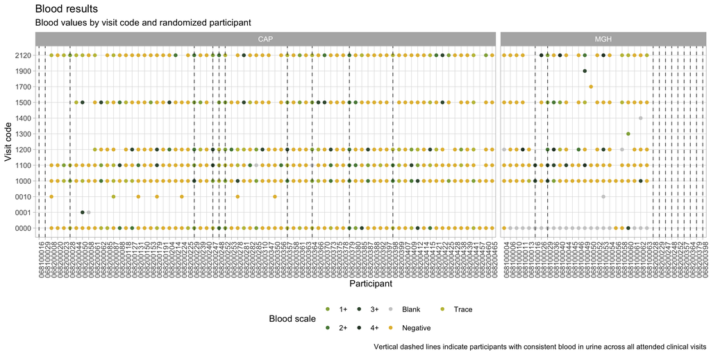

```r
tmp <- urinalysis |>
  group_by(pid) |>
  mutate(
    n_blood = sum(!is.na(blood) & blood != "Negative"),
    n_samples = sum(!is.na(blood)),
    prop_blood = n_blood / n_samples,
    flag_blood = case_when(
      prop_blood == 1 ~ "Consistent blood in urine",
      TRUE ~ "No blood in urine"
    )
  ) |>
  ungroup() |>
  select(
    pid,
    study_day,
    visit_code,
    randomized,
    visit_type,
    site,
    blood,
    n_blood,
    n_samples,
    prop_blood,
    flag_blood
  ) |>
  filter(randomized) |>
  filter(!is.na(blood))

flag_blood <- tmp |>
  filter(flag_blood == "Consistent blood in urine") |>
  pull(pid) |>
  unique()

tmp |>
  filter(!is.na(blood)) |>
  filter(randomized) |>
  ggplot() +
  aes(y = visit_code, x = pid, color = blood) +
  geom_point() +
  geom_vline(
    xintercept = flag_blood,
    linetype = "dashed",
    color = "black",
    alpha = 0.6
  ) +
  scale_color_manual(values = blood_colors) +
  facet_wrap(~site, scales = "free_x", space = "free_x") +
  theme(
    legend.position = "bottom",
    axis.text.x = element_text(angle = 90, hjust = 1)
  ) +
  labs(
    title = "Blood results",
    subtitle = "Blood values by visit code and randomized participant",
    y = "Visit code",
    x = "Participant",
    color = "Blood scale",
    caption = "Vertical dashed lines indicate participants with consistent blood in urine across all attended clinical visits"
  )
```

```r
tmp |>
  filter(flag_blood == "Consistent blood in urine") |>
  select(pid, randomized, site) |>
  arrange(pid) |>
  distinct() |>
  gt(
    caption = "Randomized participants with consistent blood in urine across all attended clinical visits"
  )
```

Randomized participants with consistent blood in urine across all attended clinical visits

| pid | randomized | site |
| --- | --- | --- |
| 068100016 | TRUE | MGH |
| 068100029 | TRUE | MGH |
| 068200028 | TRUE | CAP |
| 068200229 | TRUE | CAP |
| 068200247 | TRUE | CAP |
| 068200248 | TRUE | CAP |
| 068200252 | TRUE | CAP |
| 068200357 | TRUE | CAP |
| 068200364 | TRUE | CAP |
| 068200379 | TRUE | CAP |
| 068200398 | TRUE | CAP |

Among randomized participants, 11 participants have consistent blood in urine across all attended clinical visits. Of note, participant `068200229` has reported abnormal uterine bleeding as pre-existing condition, and participant `068100016` has reported uterine infection as pre-existing condition.

We document below the distribution of **nitrite** values in the urinalysis data.

```r
# summary table

urinalysis |>
  filter(!is.na(nitrite)) |>
  group_by(nitrite) |>
  summarise(
    n = n(),
    prop = n / nrow(urinalysis |> filter(!is.na(nitrite)))
  ) |>
  arrange(desc(n)) |>
  gt(caption = "Distribution of nitrite values in the urinalysis data") |>
  fmt_number(columns = prop, decimals = 4)
```

Distribution of nitrite values in the urinalysis data

| Nitrite | n | prop |
| --- | --- | --- |
| Negative | 867 | 0.8847 |
| Blank | 72 | 0.0735 |
| Positive | 41 | 0.0418 |

Most samples seem to have “Negative” values of nitrite, and some values are “Positive”. We document below samples for which nitrite concentration in the urine is “Positive”, by visit code and participant.

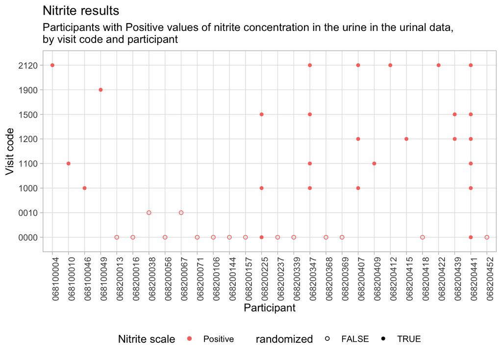

```r
urinalysis |>
  filter(!is.na(nitrite)) |>
  filter(nitrite == "Positive") |>
  select(pid, study_day, visit_code, randomized, visit_type, site, nitrite) |>
  ggplot() +
  aes(y = visit_code, x = pid, color = nitrite, shape = randomized) +
  geom_point() +
  # scale_color_manual(values = c("Negative" = "#c9c296", "Positive" = "#844452", "Blank" = "grey80")) +
  scale_shape_manual(values = c(1, 16)) +
  theme(legend.position = "bottom", axis.text.x = element_text(angle = 90)) +
  labs(
    title = "Nitrite results",
    subtitle = "Participants with Positive values of nitrite concentration in the urine in the urinal data, \nby visit code and participant",
    y = "Visit code",
    x = "Participant",
    color = "Nitrite scale"
  )
```

Participants `068200225`, `068200347`, `068200407`, `068200439` and `068200441` have been measured with “Positive” values of nitrite concentration in the urine at multiple occurrences, and all of them are randomized. None of them has reported pre-existing condition.

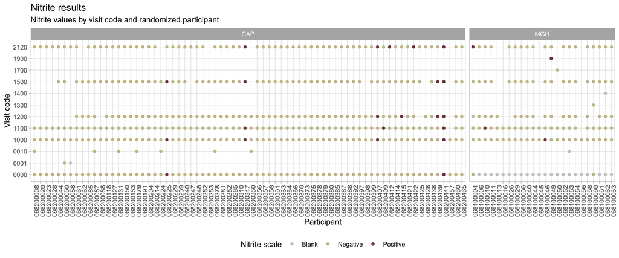

```r
# nitrite

nitrite_colors <- c(
  "Negative" = "#c9c296",
  "Positive" = "#844452",
  "Blank" = "grey80"
)

urinalysis |>
  filter(!is.na(nitrite)) |>
  filter(randomized) |>
  ggplot() +
  aes(y = visit_code, x = pid, color = nitrite) +
  geom_point() +
  scale_color_manual(values = nitrite_colors) +
  facet_wrap(~site, scales = "free_x", space = "free_x") +
  theme(
    legend.position = "bottom",
    axis.text.x = element_text(angle = 90, hjust = 1)
  ) +
  labs(
    title = "Nitrite results",
    subtitle = "Nitrite values by visit code and randomized participant",
    y = "Visit code",
    x = "Participant",
    color = "Nitrite scale"
  )
```

We document below the distribution of **leukocyte** values in the urinalysis data.

```r
# summary table

urinalysis |>
  filter(!is.na(leucocytes)) |>
  group_by(leucocytes) |>
  summarise(
    n = n(),
    prop = n / nrow(urinalysis |> filter(!is.na(leucocytes)))
  ) |>
  arrange(desc(n)) |>
  gt(caption = "Distribution of leukocyte values in the urinalysis data") |>
  fmt_number(columns = prop, decimals = 4)
```

Distribution of leukocyte values in the urinalysis data

| 0 leucocytes | n | prop |
| --- | --- | --- |
| Negative | 557 | 0.5684 |
| 1+ | 155 | 0.1582 |
| Trace | 151 | 0.1541 |
| Blank | 72 | 0.0735 |
| 3+ | 24 | 0.0245 |
| 2+ | 21 | 0.0214 |

Most samples seem to have “Negative” values of leukocyte concentration in the urine, and the rest of the values are distributed across the different levels of leukocyte concentration in the urine. With a high proportion of “Trace” and “1+” values of leukocyte concentration in the urine. We document below samples for which leukocyte concentration in the urine is higher or equal than “Trace”, by visit code and participant.

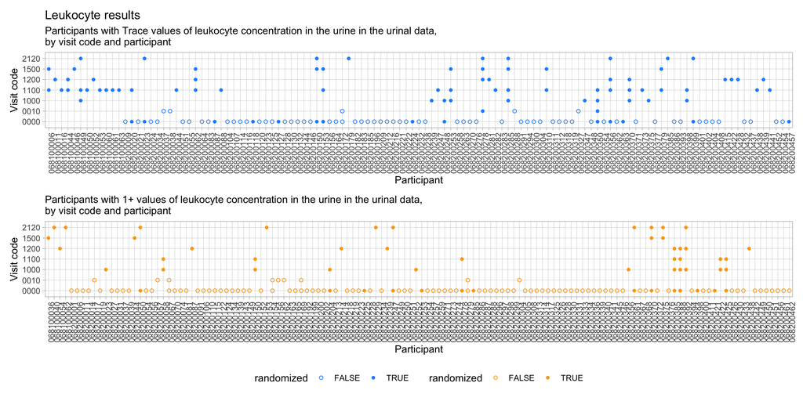

```r
urinalysis |>
  filter(!is.na(leucocytes)) |>
  filter(leucocytes == "Trace") |>
  select(
    pid,
    study_day,
    visit_code,
    randomized,
    visit_type,
    site,
    leucocytes
  ) |>
  ggplot() +
  aes(y = visit_code, x = pid, shape = randomized) +
  geom_point(color = "dodgerblue") +
  scale_shape_manual(values = c(1, 16)) +
  theme(legend.position = "bottom", axis.text.x = element_text(angle = 90)) +
  labs(
    title = "Leukocyte results",
    subtitle = "Participants with Trace values of leukocyte concentration in the urine in the urinal data, \nby visit code and participant",
    y = "Visit code",
    x = "Participant"
  ) +

  urinalysis |>
    filter(!is.na(leucocytes)) |>
    filter(leucocytes == "1+") |>
    select(
      pid,
      study_day,
      visit_code,
      randomized,
      visit_type,
      site,
      leucocytes
    ) |>
    ggplot() +
  aes(y = visit_code, x = pid, shape = randomized) +
  geom_point(color = "orange") +
  scale_shape_manual(values = c(1, 16)) +
  theme(legend.position = "bottom", axis.text.x = element_text(angle = 90)) +
  labs(
    subtitle = "Participants with 1+ values of leukocyte concentration in the urine in the urinal data, \nby visit code and participant",
    y = "Visit code",
    x = "Participant"
  ) +

  patchwork::plot_layout(ncol = 1, guides = "collect") &
  theme(legend.position = "bottom")
```

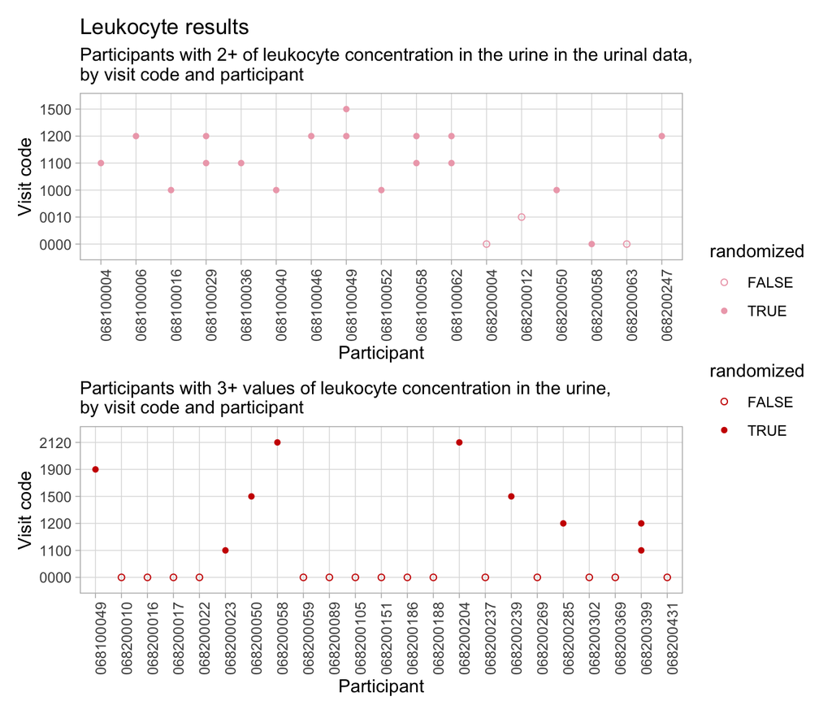

```r
urinalysis |>
  filter(!is.na(leucocytes)) |>
  filter(leucocytes == "2+") |>
  select(
    pid,
    study_day,
    visit_code,
    randomized,
    visit_type,
    site,
    leucocytes
  ) |>
  ggplot() +
  aes(y = visit_code, x = pid, shape = randomized) +
  geom_point(color = "pink2") +
  scale_shape_manual(values = c(1, 16)) +
  theme(legend.position = "bottom", axis.text.x = element_text(angle = 90)) +
  labs(
    title = "Leukocyte results",
    subtitle = "Participants with 2+ of leukocyte concentration in the urine in the urinal data, \nby visit code and participant",
    y = "Visit code",
    x = "Participant"
  ) +

  urinalysis |>
    filter(!is.na(leucocytes)) |>
    filter(leucocytes == "3+") |>
    select(
      pid,
      study_day,
      visit_code,
      randomized,
      visit_type,
      site,
      leucocytes
    ) |>
    ggplot() +
  aes(y = visit_code, x = pid, shape = randomized) +
  geom_point(color = "red3") +
  scale_shape_manual(values = c(1, 16)) +
  theme(legend.position = "bottom", axis.text.x = element_text(angle = 90)) +
  labs(
    subtitle = "Participants with 3+ values of leukocyte concentration in the urine, \nby visit code and participant",
    y = "Visit code",
    x = "Participant"
  ) +

  patchwork::plot_layout(ncol = 1, guides = "collect") &
  theme(legend.position = "right")
```

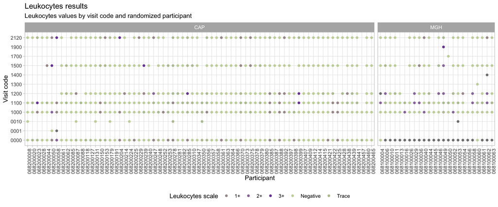

```r
# leukocytes

leukocyte_colors <- c(
  "Negative" = "#C8D4A8",
  "Trace" = "#B8C4A0",
  "1+" = "#A89898",
  "2+" = "#9878A8",
  "3+" = "#7848A0"
)

urinalysis |>
  filter(!is.na(leucocytes)) |>
  filter(randomized) |>
  ggplot() +
  aes(y = visit_code, x = pid, color = leucocytes) +
  geom_point() +
  scale_color_manual(values = leukocyte_colors) +
  facet_wrap(~site, scales = "free_x", space = "free_x") +
  theme(
    legend.position = "bottom",
    axis.text.x = element_text(angle = 90, hjust = 1)
  ) +
  labs(
    title = "Leukocytes results",
    subtitle = "Leukocytes values by visit code and randomized participant",
    y = "Visit code",
    x = "Participant",
    color = "Leukocytes scale"
  )
```

We document below the distribution of **pH** values in the urinalysis data.

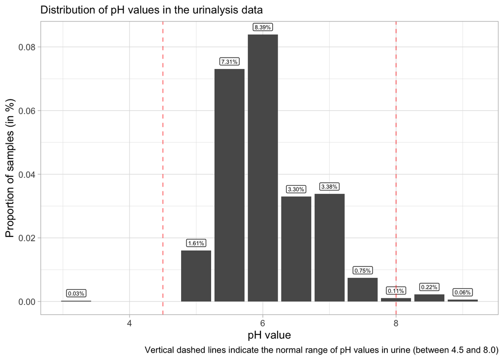

```r
# summary table

# urinalysis |>
#   filter(!is.na(ph)) |>
#   group_by(ph) |>
#   summarise(
#     n = n(),
#     prop = n / nrow(urinalysis |> filter(!is.na(ph)))
#   ) |>
#   arrange(desc(n)) |>
#   gt(caption = "Distribution of pH values in the urinalysis data") |>
#   fmt_number(columns = prop, decimals = 4)

urinalysis |>
  filter(!is.na(ph)) |>
  group_by(ph) |>
  summarise(
    n = n(),
    prop = n / nrow(urinalysis |> filter(is.na(ph)))
  ) |>
  ggplot() +
  aes(x = ph, y = prop) +
  geom_col() +
  geom_label(
    aes(label = scales::percent(prop, accuracy = 0.01)),
    vjust = -0.5,
    size = 2
  ) +
  geom_vline(xintercept = 8, linetype = "dashed", color = "red", alpha = 0.5) +
  geom_vline(
    xintercept = 4.5,
    linetype = "dashed",
    color = "red",
    alpha = 0.5
  ) +
  theme(legend.position = "bottom") +
  labs(
    subtitle = "Distribution of pH values in the urinalysis data",
    x = "pH value",
    y = "Proportion of samples (in %)",
    caption = "Vertical dashed lines indicate the normal range of pH values in urine (between 4.5 and 8.0)"
  )
```

According to several references from the American Association for Clinical Chemistry (AACC) or Mayo Clinic Laboratories, the normal range of pH values in urine is between 4.5 and 8.0, with an average value of around 6.0. We document values of pH in the urine that are outside of the normal range, by visit code and participant.

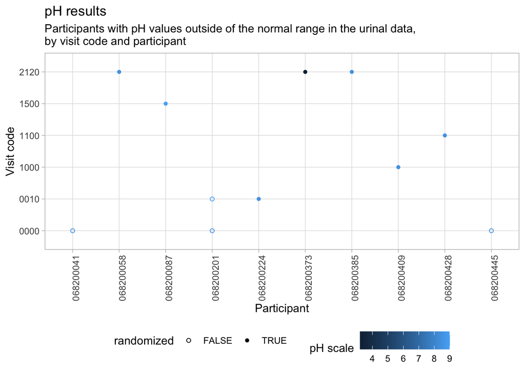

```r
urinalysis |>
  filter(!is.na(ph)) |>
  filter(ph < 4.5 | ph > 8.0) |>
  select(pid, study_day, visit_code, randomized, visit_type, site, ph) |>
  ggplot() +
  aes(y = visit_code, x = pid, color = ph, shape = randomized) +
  geom_point() +
  scale_shape_manual(values = c(1, 16)) +
  theme(legend.position = "bottom", axis.text.x = element_text(angle = 90)) +
  labs(
    title = "pH results",
    subtitle = "Participants with pH values outside of the normal range in the urinal data, \nby visit code and participant",
    y = "Visit code",
    x = "Participant",
    color = "pH scale"
  )
```

```r
urinalysis |>
  filter(!is.na(ph)) |>
  filter(ph < 4.5 | ph > 8.0) |>
  select(pid, study_day, visit_code, randomized, visit_type, site, ph) |>
  arrange(pid, visit_code) |>
  gt(
    caption = "Participants with pH values outside of the normal range in the urinalysis data"
  ) |>
  tab_style(
    style = cell_fill(color = "#FFCCCC"),
    locations = cells_body(rows = ph < 4.5)
  ) |>
  tab_style(
    style = cell_fill(color = "#ADD8E6"),
    locations = cells_body(rows = ph > 8.0)
  )
```

Participants with pH values outside of the normal range in the urinalysis data

| pid | study_day | visit_code | randomized | visit_type | site | Ph value |
| --- | --- | --- | --- | --- | --- | --- |
| 068200041 | 0 | 0000 | FALSE | Clinic | CAP | 8.5 |
| 068200058 | 85 | 2120 | TRUE | Clinic | CAP | 8.5 |
| 068200087 | 40 | 1500 | TRUE | Clinic | CAP | 9.0 |
| 068200201 | -8 | 0000 | FALSE | Clinic | CAP | 8.5 |
| 068200201 | 0 | 0010 | FALSE | Unclear | CAP | 9.0 |
| 068200224 | -6 | 0010 | TRUE | Unclear | CAP | 8.5 |
| 068200373 | 70 | 2120 | TRUE | Clinic | CAP | 3.2 |
| 068200385 | 74 | 2120 | TRUE | Clinic | CAP | 8.5 |
| 068200409 | 0 | 1000 | TRUE | Clinic | CAP | 8.5 |
| 068200428 | 7 | 1100 | TRUE | Clinic | CAP | 8.5 |
| 068200445 | 0 | 0000 | FALSE | Clinic | CAP | 8.5 |

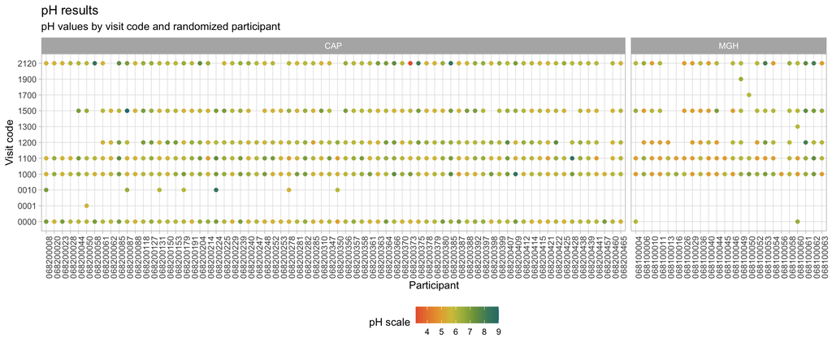

```r
# pH

ph_colors <- c(
  "#E8613A",
  "#E8A83A",
  "#D4C44A",
  "#A8B84A",
  "#7A9E4A",
  "#4A8A6A",
  "#2A7A7A"
)

urinalysis |>
  filter(!is.na(ph)) |>
  filter(randomized) |>
  ggplot() +
  aes(y = visit_code, x = pid, color = ph) +
  geom_point() +
  scale_color_gradientn(
    colors = ph_colors,
    values = scales::rescale(c(5.0, 6.0, 6.5, 7.0, 7.5, 8.0, 8.5))
  ) +
  facet_wrap(~site, scales = "free_x", space = "free_x") +
  theme(
    legend.position = "bottom",
    axis.text.x = element_text(angle = 90, hjust = 1)
  ) +
  labs(
    title = "pH results",
    subtitle = "pH values by visit code and randomized participant",
    y = "Visit code",
    x = "Participant",
    color = "pH scale"
  )
```

We document below the distribution of the continuous variable **urobilinogen** in the urinalysis data.

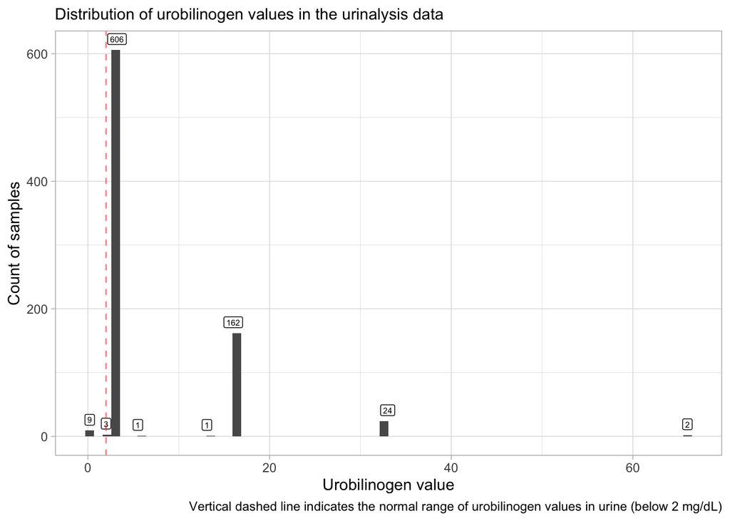

```r
# summary plot

urinalysis |>
  filter(!is.na(urobilinogen)) |>
  ggplot() +
  aes(x = urobilinogen) +
  geom_histogram(bins = 70) +
  geom_label(
    stat = "count",
    aes(label = after_stat(count)),
    vjust = -0.5,
    size = 2
  ) +
  geom_vline(xintercept = 2, linetype = "dashed", color = "red", alpha = 0.5) +
  theme(legend.position = "bottom") +
  labs(
    subtitle = "Distribution of urobilinogen values in the urinalysis data",
    x = "Urobilinogen value",
    y = "Count of samples",
    caption = "Vertical dashed line indicates the normal range of urobilinogen values in urine (below 2 mg/dL)"
  )
```

**Warning**

Most samples had urobilinogen values above the normal range (above 2 mg/dL). I am not sure whether the units are mg/dL, mg/L or µmol/L. In the first scenario, 33 mg/dL or 66 mg/dL seems unrealistic; it may also be an encoding issue, as we expect values between 0.2 and 8 mg/dL.

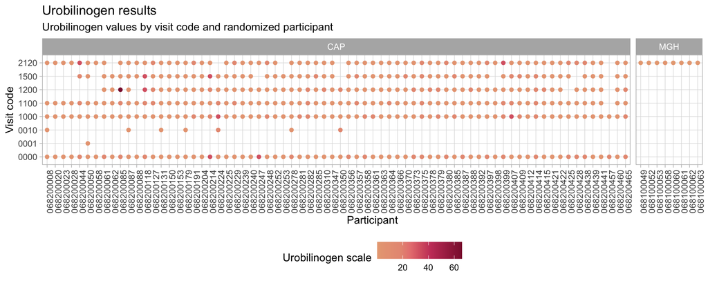

```r
# urobilinogen

urobilinogen_colors <- c(
  "#E8A882",
  "#E89882",
  "#E88080",
  "#D86070",
  "#C84068",
  "#8B1a3a"
)

urinalysis |>
  filter(!is.na(urobilinogen)) |>
  filter(randomized) |>
  ggplot() +
  aes(y = visit_code, x = pid, color = urobilinogen) +
  geom_point() +
  scale_color_gradientn(
    colors = urobilinogen_colors,
    values = scales::rescale(log(c(0.2, 1, 2, 4, 8, 66)))
  ) +
  facet_wrap(~site, scales = "free_x", space = "free_x") +
  theme(
    legend.position = "bottom",
    axis.text.x = element_text(angle = 90, hjust = 1)
  ) +
  labs(
    title = "Urobilinogen results",
    subtitle = "Urobilinogen values by visit code and randomized participant",
    y = "Visit code",
    x = "Participant",
    color = "Urobilinogen scale"
  )
```

We document below the distribution of **protein** values in the urinalysis data.

```r
# summary table

urinalysis |>
  filter(!is.na(protein)) |>
  group_by(protein) |>
  summarise(
    n = n(),
    prop = n / nrow(urinalysis |> filter(!is.na(protein)))
  ) |>
  arrange(desc(n)) |>
  gt(caption = "Distribution of protein values in the urinalysis data") |>
  fmt_number(columns = prop, decimals = 4)
```

Distribution of protein values in the urinalysis data

| Protein | n | prop |
| --- | --- | --- |
| Negative | 626 | 0.6388 |
| Trace | 162 | 0.1653 |
| 1+ | 102 | 0.1041 |
| Blank | 67 | 0.0684 |
| 2+ | 20 | 0.0204 |
| 3+ | 3 | 0.0031 |

Most samples seem to have “Negative” values of protein concentration in the urine, and the rest of the values are distributed across the different levels of protein concentration in the urine. With a high proportion of “Trace” values of protein concentration in the urine. We document below samples for which protein concentration in the urine is higher or equal than “2+”, by visit code and participant.

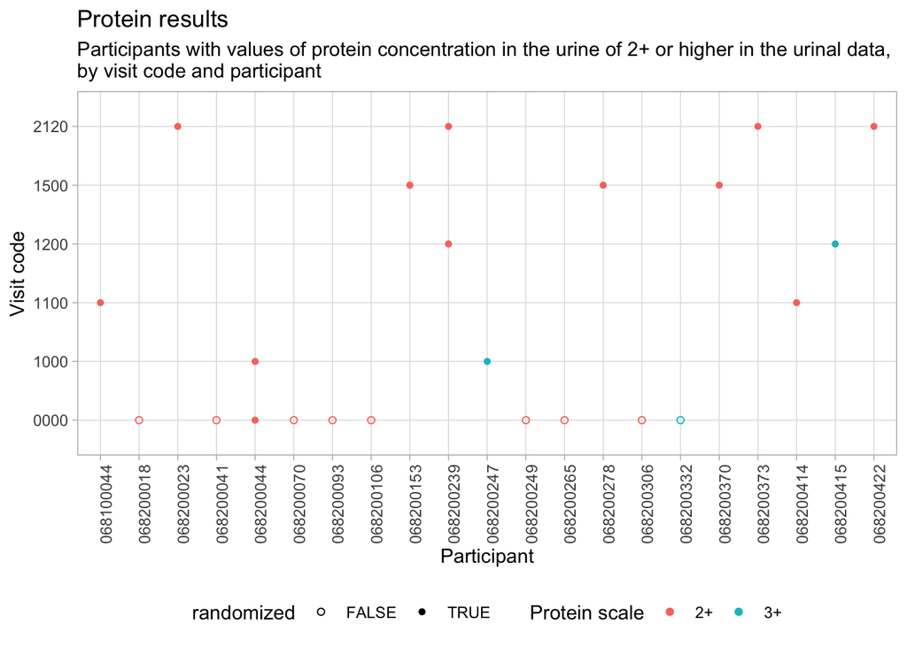

```r
urinalysis |>
  filter(!is.na(protein)) |>
  filter(protein == "2+" | protein == "3+") |>
  select(pid, study_day, visit_code, randomized, visit_type, site, protein) |>
  ggplot() +
  aes(y = visit_code, x = pid, color = protein, shape = randomized) +
  geom_point() +
  scale_shape_manual(values = c(1, 16)) +
  theme(legend.position = "bottom", axis.text.x = element_text(angle = 90)) +
  labs(
    title = "Protein results",
    subtitle = "Participants with values of protein concentration in the urine of 2+ or higher in the urinal data, \nby visit code and participant",
    y = "Visit code",
    x = "Participant",
    color = "Protein scale"
  )
```

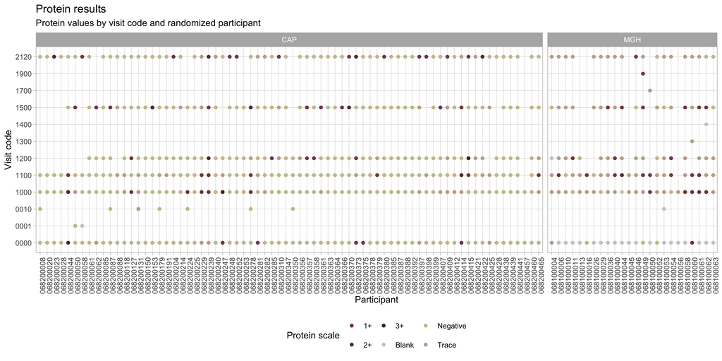

```r
# protein

protein_colors <- c(
  "Negative" = "#c9c296",
  "Trace" = "#c2ac94",
  "1+" = "#844452",
  "2+" = "#63333f",
  "3+" = "#4d2e2b",
  "4+" = "#3a1f1e",
  "Blank" = "grey80"
)

urinalysis |>
  filter(!is.na(protein)) |>
  filter(randomized) |>
  ggplot() +
  aes(y = visit_code, x = pid, color = protein) +
  geom_point() +
  scale_color_manual(values = protein_colors) +
  facet_wrap(~site, scales = "free_x", space = "free_x") +
  theme(
    legend.position = "bottom",
    axis.text.x = element_text(angle = 90, hjust = 1)
  ) +
  labs(
    title = "Protein results",
    subtitle = "Protein values by visit code and randomized participant",
    y = "Visit code",
    x = "Participant",
    color = "Protein scale"
  )
```

We document below the distribution of **specific gravity** values in the urinalysis data.

Two variables are available in the urinalysis data: `specific_gravity_value`, which is a continuous variable, and `specific_gravity_signs`, which is a categorical variable with values such as “>=” or “<=”.

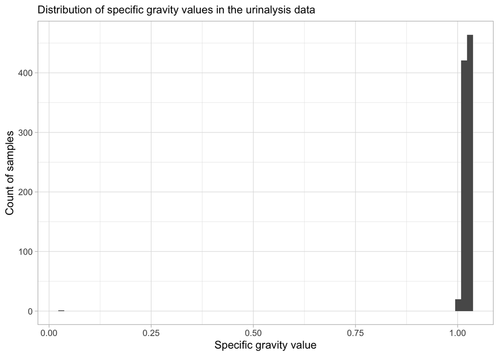

```r
# summary plot

urinalysis |>
  filter(!is.na(specific_gravity_value)) |>
  ggplot() +
  aes(x = specific_gravity_value) +
  geom_histogram(bins = 70) +
  # geom_label(stat = "count", aes(label = after_stat(count)), vjust = -0.5, size = 2) +
  # geom_vline(xintercept = c(1.005, 1.025), linetype = "dashed", color = "red", alpha = 0.5) +
  theme(legend.position = "bottom") +
  labs(
    subtitle = "Distribution of specific gravity values in the urinalysis data",
    x = "Specific gravity value",
    y = "Count of samples"
  )
```

We see an very low specific gravity value, which may be an encoding issue. We document this value below.

```r
urinalysis |>
  filter(!is.na(specific_gravity_value)) |>
  filter(specific_gravity_value < 0.5) |>
  select(
    pid,
    study_day,
    visit_code,
    randomized,
    visit_type,
    site,
    specific_gravity_value
  ) |>
  arrange(pid, visit_code) |>
  gt(
    caption = "Participants with specific gravity values below the normal range in the urinalysis data"
  )
```

Participants with specific gravity values below the normal range in the urinalysis data

| pid | study_day | visit_code | randomized | visit_type | site | specific_gravity_value |
| --- | --- | --- | --- | --- | --- | --- |
| 068200193 | 0 | 0000 | FALSE | Clinic | CAP | 0.03 |

For this non-randomized participant, there is only one measured value of specific gravity, which seems very low, but al of the other constants in the urinalysis data for this participant are within the normal range, and there is no documented preexisting condition.

**Warning**

This value of specific gravity seems to be an outlier, and it may be an encoding issue, but I cannot be sure.

We document the distribution of specific gravity values in the urine excluding this potential outlier, by visit code and participant.

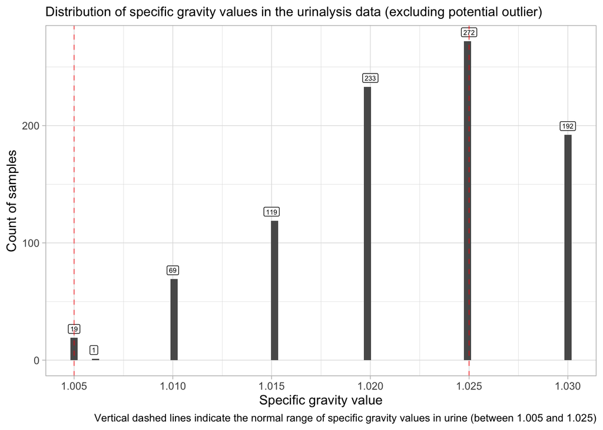

```r
urinalysis |>
  filter(!is.na(specific_gravity_value)) |>
  filter(specific_gravity_value >= 0.5) |>
  select(
    pid,
    study_day,
    visit_code,
    randomized,
    visit_type,
    site,
    specific_gravity_value
  ) |>
  ggplot() +
  aes(x = specific_gravity_value) +
  geom_histogram(bins = 70) +
  geom_label(
    stat = "count",
    aes(label = after_stat(count)),
    vjust = -0.5,
    size = 2
  ) +
  geom_vline(
    xintercept = c(1.005, 1.025),
    linetype = "dashed",
    color = "red",
    alpha = 0.5
  ) +
  theme(legend.position = "bottom") +
  labs(
    subtitle = "Distribution of specific gravity values in the urinalysis data (excluding potential outlier)",
    x = "Specific gravity value",
    y = "Count of samples",
    caption = "Vertical dashed lines indicate the normal range of specific gravity values in urine (between 1.005 and 1.025)"
  )
```

We now document the specific gravity with the `specific_gravity_signs` variable, by visit code and participant.

```r
# summary table

urinalysis |>
  filter(!is.na(specific_gravity_signs)) |>
  group_by(specific_gravity_signs) |>
  summarise(
    n = n(),
    prop = n / nrow(urinalysis |> filter(!is.na(specific_gravity_signs)))
  ) |>
  arrange(desc(n)) |>
  gt(
    caption = "Distribution of specific gravity signs in the urinalysis data"
  ) |>
  fmt_number(columns = prop, decimals = 4)
```

Distribution of specific gravity signs in the urinalysis data

| Specific gravity signs | n | prop |
| --- | --- | --- |
| Blank | 684 | 0.6980 |
| >= | 202 | 0.2061 |
| <= | 94 | 0.0959 |

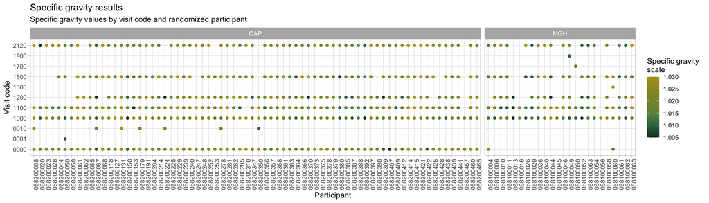

```r
# specific gravity

specific_gravity_colors <- c(
  "#1a3d2b",
  "#2d6b4a",
  "#5a8a4a",
  "#7a9440",
  "#8b9130",
  "#a0962a",
  "#b5a020"
)

urinalysis |>
  filter(!is.na(specific_gravity_value)) |>
  filter(randomized) |>
  ggplot() +
  aes(y = visit_code, x = pid, color = specific_gravity_value) +
  geom_point() +
  scale_color_gradientn(
    colors = specific_gravity_colors,
    values = scales::rescale(c(1.000, 1.005, 1.010, 1.015, 1.020, 1.025, 1.030))
  ) +
  facet_wrap(~site, scales = "free_x", space = "free_x") +
  theme(
    legend.position = "right",
    axis.text.x = element_text(angle = 90, hjust = 1)
  ) +
  labs(
    title = "Specific gravity results",
    subtitle = "Specific gravity values by visit code and randomized participant",
    y = "Visit code",
    x = "Participant",
    color = "Specific gravity \nscale"
  )
```

### Pregnancy test results

In this study, two types of pregnancy tests were performed: urine pregnancy test and blood BHCG pregnancy test. We document below the distribution of the results of these two types of pregnancy tests.

```r
pregnancy <-
  mae@metadata$visits_crfs_merged |>
  select(
    uid,
    pregnancy_not_applicable,
    pregnancy_test_urine,
    pregnancy_test_bhcg
  ) |>
  left_join(
    mae@colData |>
      as_tibble() |>
      select(uid, pid, study_day, visit_code, visit_type, randomized, site),
    by = join_by(uid)
  )
```

We first document the variable for **urine pregnancy test**, which is a categorical variable with values “Negative”, “Positive”, “Indeterminate” or “Blank”, as documented in CRF3. We document the distribution of these values in the urine pregnancy test data, and then we document the samples with “Positive” or “Indeterminate” values of urine pregnancy test results, by visit code and participant.

```r
# summary table for urine pregnancy test

pregnancy |>
  filter(!is.na(pregnancy_test_urine)) |>
  group_by(pregnancy_test_urine) |>
  summarise(
    n = n(),
    prop = n / nrow(pregnancy |> filter(!is.na(pregnancy_test_urine)))
  ) |>
  arrange(desc(n)) |>
  gt(
    caption = "Distribution of urine pregnancy test results in the pregnancy data"
  ) |>
  fmt_number(columns = prop, decimals = 4)
```

Distribution of urine pregnancy test results in the pregnancy data

| pregnancy_test_urine | n | prop |
| --- | --- | --- |
| Negative | 832 | 0.8490 |
| Blank | 145 | 0.1480 |
| Positive | 3 | 0.0031 |

Only 3 samples have “Positive” values of urine pregnancy test results. We document these samples below.

```r
pregnancy |>
  filter(!is.na(pregnancy_test_urine)) |>
  filter(pregnancy_test_urine == "Positive") |>
  select(
    pid,
    study_day,
    visit_code,
    randomized,
    visit_type,
    site,
    pregnancy_test_urine
  ) |>
  gt(
    caption = "Participants with Positive values of urine pregnancy test results in the pregnancy data"
  )
```

Participants with Positive values of urine pregnancy test results in the pregnancy data

| pid | study_day | visit_code | randomized | visit_type | site | pregnancy_test_urine |
| --- | --- | --- | --- | --- | --- | --- |
| 068200183 | 0 | 0000 | FALSE | Clinic | CAP | Positive |
| 068200277 | 0 | 0000 | FALSE | Clinic | CAP | Positive |
| 068100018 | 0 | 0000 | FALSE | Clinic | MGH | Positive |

Those three values of positive urine pregnancy test results are from non-randomized participants, measured at baseline visit 0000.

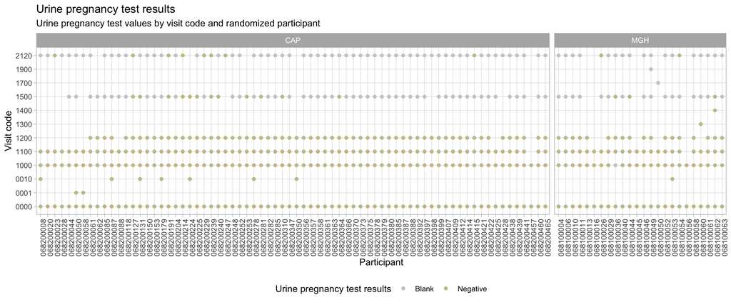

```r
pregnancy |>
  filter(!is.na(pregnancy_test_urine)) |>
  filter(randomized) |>
  ggplot() +
  aes(y = visit_code, x = pid, color = pregnancy_test_urine) +
  geom_point() +
  scale_color_manual(
    values = c(
      "Negative" = "#c9c296",
      "Positive" = "#844452",
      "Indeterminate" = "#E8A882",
      "Blank" = "grey80"
    )
  ) +
  facet_wrap(~site, scales = "free_x", space = "free_x") +
  theme(legend.position = "bottom", axis.text.x = element_text(angle = 90)) +
  labs(
    title = "Urine pregnancy test results",
    subtitle = "Urine pregnancy test values by visit code and randomized participant",
    y = "Visit code",
    x = "Participant",
    color = "Urine pregnancy test results"
  )
```

We now document the variable for **blood BHCG pregnancy test**. We document the distribution of these values in the blood pregnancy test data.

```r
# summary table for blood BHCG pregnancy test

pregnancy |>
  filter(!is.na(pregnancy_test_bhcg)) |>
  group_by(pregnancy_test_bhcg) |>
  summarise(
    n = n(),
    prop = n / nrow(pregnancy |> filter(!is.na(pregnancy_test_bhcg)))
  ) |>
  arrange(desc(n)) |>
  gt(
    caption = "Distribution of blood BHCG pregnancy test results in the pregnancy data"
  ) |>
  fmt_number(columns = prop, decimals = 4)
```

Distribution of blood BHCG pregnancy test results in the pregnancy data

| pregnancy_test_bhcg | n | prop |
| --- | --- | --- |
| Not applicable | 836 | 0.8531 |
| Blank | 144 | 0.1469 |

Only “Non applicable” and “Blank” levels are available in this variable, which makes sense since BCGH blood tests were only performed if urine pregnancy results were indeterminate.

### Vagina-related test results

Among vagina-related variables, we document the measured vaginal pH and results from clue cells and whiff test.

```r
vagina_tests <-
  mae@metadata$visits_crfs_merged |>
  select(
    uid,
    clue_cells,
    whiff_test,
    vaginal_ph
  ) |>
  left_join(
    mae@colData |>
      as_tibble() |>
      select(uid, pid, study_day, visit_code, visit_type, randomized, site),
    by = join_by(uid)
  )
```

We first document the **vaginal pH** variable distribution, by visit code and participant.

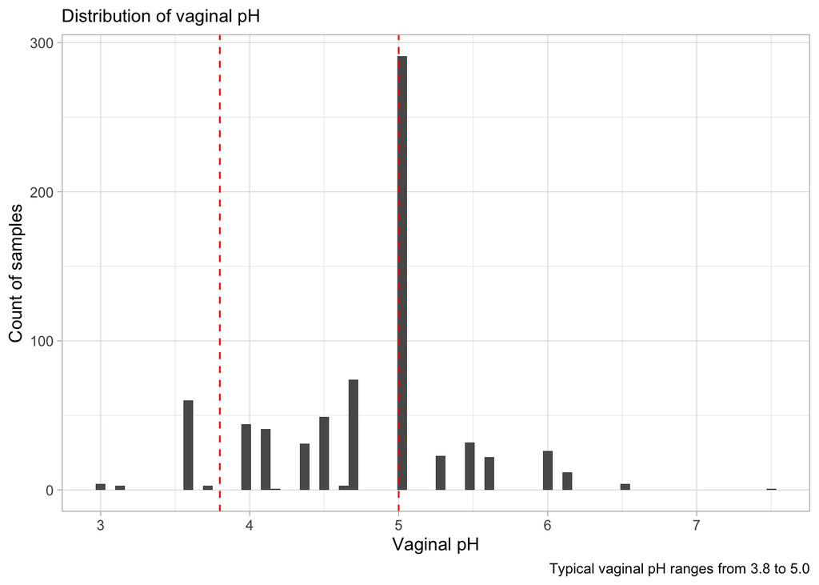

```r
vagina_tests |>
  filter(!is.na(vaginal_ph)) |>
  ggplot() +
  aes(x = vaginal_ph) +
  geom_histogram(bins = 70) +
  theme(legend.position = "bottom") +
  geom_vline(xintercept = 3.8, color = "red", linetype = "dashed") +
  geom_vline(xintercept = 5, color = "red", linetype = "dashed") +
  labs(
    subtitle = "Distribution of vaginal pH",
    x = "Vaginal pH",
    y = "Count of samples",
    caption = "Typical vaginal pH ranges from 3.8 to 5.0"
  )
```

We document samples for which vaginal pH is outside of the typical range, by visit code and participant.

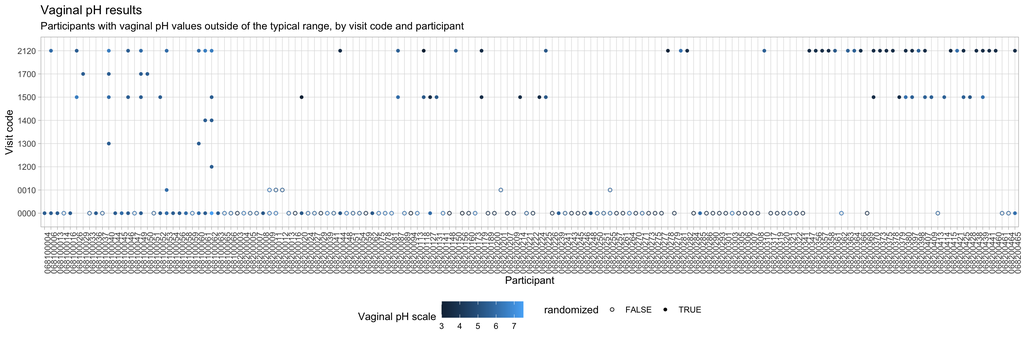

```r
vagina_tests |>
  filter(!is.na(vaginal_ph)) |>
  filter(vaginal_ph < 3.8 | vaginal_ph > 5) |>
  select(
    pid,
    study_day,
    visit_code,
    randomized,
    visit_type,
    site,
    vaginal_ph
  ) |>
  ggplot() +
  aes(y = visit_code, x = pid, color = vaginal_ph, shape = randomized) +
  geom_point() +
  scale_shape_manual(values = c(1, 16)) +
  theme(legend.position = "bottom", axis.text.x = element_text(angle = 90)) +
  labs(
    title = "Vaginal pH results",
    subtitle = "Participants with vaginal pH values outside of the typical range, by visit code and participant",
    y = "Visit code",
    x = "Participant",
    color = "Vaginal pH scale"
  )
```

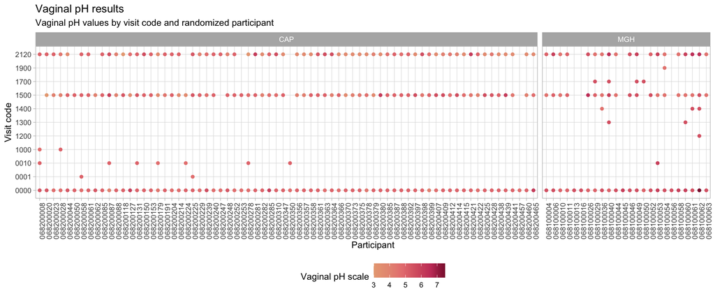

```r
# summary results plot

vagina_tests |>
  filter(!is.na(vaginal_ph)) |>
  filter(randomized) |>
  ggplot() +
  aes(y = visit_code, x = pid, color = vaginal_ph) +
  geom_point() +
  scale_color_gradientn(
    colors = c(
      "#E8A882",
      "#E89882",
      "#E88080",
      "#D86070",
      "#C84068",
      "#8B1a3a"
    ),
    values = scales::rescale(c(3.5, 4.0, 4.5, 5.0, 5.5))
  ) +
  facet_wrap(~site, scales = "free_x", space = "free_x") +
  theme(
    legend.position = "bottom",
    axis.text.x = element_text(angle = 90, hjust = 1)
  ) +
  labs(
    title = "Vaginal pH results",
    subtitle = "Vaginal pH values by visit code and randomized participant",
    y = "Visit code",
    x = "Participant",
    color = "Vaginal pH scale"
  )
```

We now document the distribution of **clue cells** results, which is a categorical variable with values “Negative”, “Positive”, by visit code and participant.

```r
# summary table

vagina_tests |>
  filter(!is.na(clue_cells)) |>
  group_by(clue_cells) |>
  summarise(
    n = n(),
    prop = n / nrow(vagina_tests |> filter(!is.na(clue_cells)))
  ) |>
  arrange(desc(n)) |>
  gt(caption = "Distribution of clue cells levels in vaginal test") |>
  fmt_number(columns = prop, decimals = 4)
```

Distribution of clue cells levels in vaginal test

| clue_cells | n | prop |
| --- | --- | --- |
| Negative | 427 | 0.5882 |
| Positive | 299 | 0.4118 |

We summarize the results for randomized samples below.

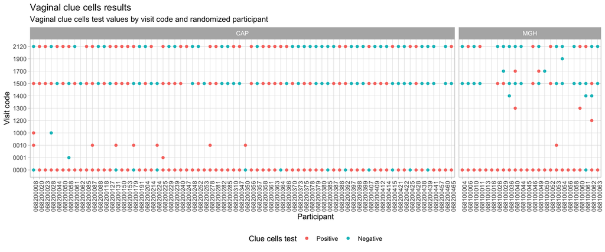

```r
vagina_tests |>
  filter(!is.na(clue_cells)) |>
  filter(randomized) |>
  ggplot() +
  aes(y = visit_code, x = pid, color = clue_cells) +
  geom_point() +
  facet_wrap(~site, scales = "free_x", space = "free_x") +
  theme(
    legend.position = "bottom",
    axis.text.x = element_text(angle = 90, hjust = 1)
  ) +
  labs(
    title = "Vaginal clue cells results",
    subtitle = "Vaginal clue cells test values by visit code and randomized participant",
    y = "Visit code",
    x = "Participant",
    color = "Clue cells test"
  )
```

```r
# summary table

vagina_tests |>
  filter(!is.na(whiff_test)) |>
  group_by(whiff_test) |>
  summarise(
    n = n(),
    prop = n / nrow(vagina_tests |> filter(!is.na(whiff_test)))
  ) |>
  arrange(desc(n)) |>
  gt(caption = "Distribution of whiff test results levels in vaginal test") |>
  fmt_number(columns = prop, decimals = 4)
```

Distribution of whiff test results levels in vaginal test

| whiff_test | n | prop |
| --- | --- | --- |
| Negative | 457 | 0.6295 |
| Positive | 269 | 0.3705 |

We summarize the results for randomized samples below.

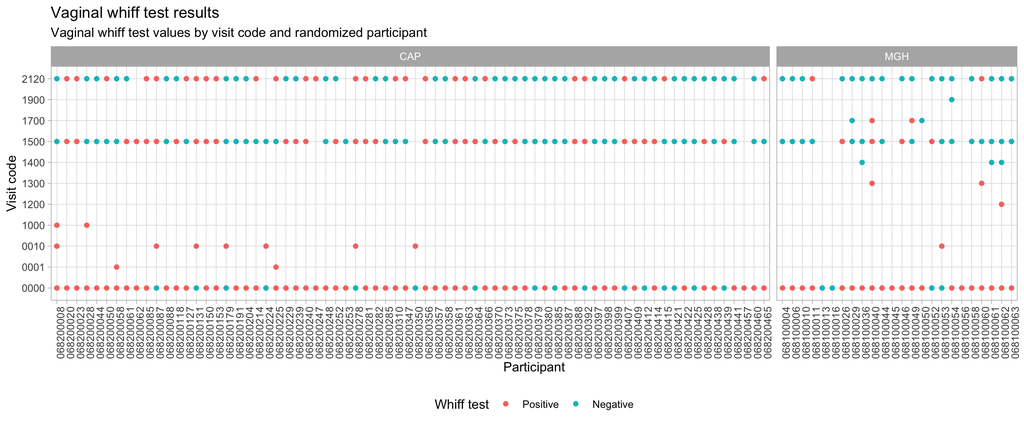

```r
vagina_tests |>
  filter(!is.na(whiff_test)) |>
  filter(randomized) |>
  ggplot() +
  aes(y = visit_code, x = pid, color = whiff_test) +
  geom_point() +
  facet_wrap(~site, scales = "free_x", space = "free_x") +
  theme(
    legend.position = "bottom",
    axis.text.x = element_text(angle = 90, hjust = 1)
  ) +
  labs(
    title = "Vaginal whiff test results",
    subtitle = "Vaginal whiff test values by visit code and randomized participant",
    y = "Visit code",
    x = "Participant",
    color = "Whiff test"
  )
```

# Saving the `MultiAssayExperiment` objects

We save the MAE for downstream analyses.

```r
saveRDS(
  mae,
  str_c(
    get_03_output_dir(),
    "mae_full_06_",
    today() |> str_remove_all("-"),
    ".rds"
  )
)
```